https://prinaldi3.github.io

# Mice Protein Expression Analysis

Phil Rinaldi and Molly Lyons, CMPS 3160

## Milestone 1

### Introduction

For our project, we will investigate a dataset on mice protein expression that we found on Kaggle (https://www.kaggle.com/ruslankl/mice-protein-expression). This dataset contains information on proteins that are expressed in several conditions in mice, including when mice are treated with the drug memantine (a drug used to treat Alzheimer's disease). We want to use the data to determine the effect memantine on the mice. The data contains 1080 measurements of expression per protein, for 72 mice (and each mouse had 15 measurements taken on it). The data has already been neatly categorized by the experimental conditions to which the mice were subjected and their biological traits (specifically trisomic or control gene, injected/not injected with memantine, stimulated/not stimulated to learn).

### Project and Collaboration Plan

We are currently looking at a dataset about mice protein expression (https://www.kaggle.com/ruslankl/mice-protein-expression). This dataset contains information on proteins that are expressed in several conditions in mice, including when mice are treated with the drug memantine (a drug used to treat Alzheimer's disease). We want to use the data to determine the effect memantine on the mice. Also, memantine is NMDA receptor antagonist like the drug ketamine, which is being researched as a fast-acting antidepressant, so we were thinking of finding another dataset related to depression and Alzheimer's to see if there is some correlation between NMDA receptors, Alzheimer's, and depression. It might be difficult to find datasets that have exactly what we are looking for, which would be proteins that are over or under expressed in major depression, during ketamine use, and in people with Alzheimer's disease. The Psychiatric Genomics Consortium has data on major depressive disorder, though it is unclear what form the data is in (entire genome, proteins expressed, etc.). We also must apply to download the data from the Psychiatric Genomics Consortium, which poses the risk that we might not be able to get access to the data. There is a microarray analysis on Alzheimer’s disease on Kaggle (https://www.kaggle.com/andrewgao/alzheimer-microarray-analysis), which could be of use to us if we decide to take this direction for our final tutorial. Particularly, the mice protein expression data contains 1080 measurements of expression per protein, for 72 mice. The data has already been neatly categorized by the experimental conditions to which the mice were subjected and their biological traits (trisomic or control gene, injected/not injected with memantic, etc.)

Two other datasets we found are ones pertaining to structural proteins and genes related to pancreatic cancer. (https://www.kaggle.com/shahir/protein-data-set and https://www.kaggle.com/abhiparashar/cancer-prediction, respectively. It was a bit difficult for us to formulate reasonable queries, as these are enormous sets of data and are intended for a wide range of research. Though these datasets are broad, we could look for overall trends that might help point us in a more specific direction. Additionally, it might be very difficult for a pair of undergraduates, one of whom does not study Biology, would be able to carry out any project of such magnitude without proper expertise and guidance. We are both in agreement that we want to work with a biological dataset, so even if our previously chosen datasets do not work out we are confident that we will be able to find another one that works.

We met on Zoom once to set up the github.io public page, share access to it, and establish a google doc to write up our milestone. We plan on zooming again next week, and will likely continue to meet bi-weekly for the remainder of the project. We will also establish a private github repository where we can collaborate on code.

### Data Extraction, Transform, and Loading

```python
import pandas as pd
import numpy as np
import matplotlib.pyplot as plt


#Opening data in pandas dataframe
df_proteins = pd.read_csv("./Data/Data_Cortex_Nuclear.csv")

#Setting index so all values in table are the same observational unit
#df_proteins.set_index(["Genotype", "Treatment", "Behavior", "class"], inplace=True)

df_proteins
```

|  | MouseID | DYRK1A_N | ITSN1_N | BDNF_N | NR1_N | NR2A_N | pAKT_N | pBRAF_N | pCAMKII_N | pCREB_N | ... | pCFOS_N | SYP_N | H3AcK18_N | EGR1_N | H3MeK4_N | CaNA_N | Genotype | Treatment | Behavior | class |
| --- | --- | --- | --- | --- | --- | --- | --- | --- | --- | --- | --- | --- | --- | --- | --- | --- | --- | --- | --- | --- | --- |
| 0 | 309_1 | 0.503644 | 0.747193 | 0.430175 | 2.816329 | 5.990152 | 0.218830 | 0.177565 | 2.373744 | 0.232224 | ... | 0.108336 | 0.427099 | 0.114783 | 0.131790 | 0.128186 | 1.675652 | Control | Memantine | C/S | c-CS-m |
| 1 | 309_2 | 0.514617 | 0.689064 | 0.411770 | 2.789514 | 5.685038 | 0.211636 | 0.172817 | 2.292150 | 0.226972 | ... | 0.104315 | 0.441581 | 0.111974 | 0.135103 | 0.131119 | 1.743610 | Control | Memantine | C/S | c-CS-m |
| 2 | 309_3 | 0.509183 | 0.730247 | 0.418309 | 2.687201 | 5.622059 | 0.209011 | 0.175722 | 2.283337 | 0.230247 | ... | 0.106219 | 0.435777 | 0.111883 | 0.133362 | 0.127431 | 1.926427 | Control | Memantine | C/S | c-CS-m |
| 3 | 309_4 | 0.442107 | 0.617076 | 0.358626 | 2.466947 | 4.979503 | 0.222886 | 0.176463 | 2.152301 | 0.207004 | ... | 0.111262 | 0.391691 | 0.130405 | 0.147444 | 0.146901 | 1.700563 | Control | Memantine | C/S | c-CS-m |
| 4 | 309_5 | 0.434940 | 0.617430 | 0.358802 | 2.365785 | 4.718679 | 0.213106 | 0.173627 | 2.134014 | 0.192158 | ... | 0.110694 | 0.434154 | 0.118481 | 0.140314 | 0.148380 | 1.839730 | Control | Memantine | C/S | c-CS-m |
| ... | ... | ... | ... | ... | ... | ... | ... | ... | ... | ... | ... | ... | ... | ... | ... | ... | ... | ... | ... | ... | ... |
| 1075 | J3295_11 | 0.254860 | 0.463591 | 0.254860 | 2.092082 | 2.600035 | 0.211736 | 0.171262 | 2.483740 | 0.207317 | ... | 0.183324 | 0.374088 | 0.318782 | 0.204660 | 0.328327 | 1.364823 | Ts65Dn | Saline | S/C | t-SC-s |
| 1076 | J3295_12 | 0.272198 | 0.474163 | 0.251638 | 2.161390 | 2.801492 | 0.251274 | 0.182496 | 2.512737 | 0.216339 | ... | 0.175674 | 0.375259 | 0.325639 | 0.200415 | 0.293435 | 1.364478 | Ts65Dn | Saline | S/C | t-SC-s |
| 1077 | J3295_13 | 0.228700 | 0.395179 | 0.234118 | 1.733184 | 2.220852 | 0.220665 | 0.161435 | 1.989723 | 0.185164 | ... | 0.158296 | 0.422121 | 0.321306 | 0.229193 | 0.355213 | 1.430825 | Ts65Dn | Saline | S/C | t-SC-s |
| 1078 | J3295_14 | 0.221242 | 0.412894 | 0.243974 | 1.876347 | 2.384088 | 0.208897 | 0.173623 | 2.086028 | 0.192044 | ... | 0.196296 | 0.397676 | 0.335936 | 0.251317 | 0.365353 | 1.404031 | Ts65Dn | Saline | S/C | t-SC-s |
| 1079 | J3295_15 | 0.302626 | 0.461059 | 0.256564 | 2.092790 | 2.594348 | 0.251001 | 0.191811 | 2.361816 | 0.223632 | ... | 0.187556 | 0.420347 | 0.335062 | 0.252995 | 0.365278 | 1.370999 | Ts65Dn | Saline | S/C | t-SC-s |

1080 rows × 82 columns

Looking at the dataframe, there are 15 measurements for each mouse. For our future analysis we will most likely be taking the mean of the 15 measurements for each mouse, for each protein. There are 77 proteins expressed and 72 mice total, so we will have a total of 5544 data points on protein expression.

## Milestone 2

### Exploratory Analysis

As stated above, we will begin by taking the mean of the 15 measurements of protein expression for each mouse. First, however, a bit more manipulation of the data is necessary. The MouseID column contains two bits of information -- the mouse that was experimented on, and the number of the measurement that any particular row represents (i.e. 309_1 denotes the first measurement taken on mouse 309). We split this column into two columns -- one for the mouse and one for the measurement number -- so that we could then easily group by mouse and take the average of the protein expression data over the 15 trials.

```python
df_proteins["Mouse"] = df_proteins["MouseID"].str.split("_", expand=True)[0]
df_proteins["Measurement#"] = df_proteins["MouseID"].str.split("_", expand=True)[1]
df_proteins.drop(columns="MouseID", inplace=True)
df_proteins = df_proteins.set_index(["Genotype", "Treatment", "Behavior", "Measurement#"])
df_proteins
```

| Genotype | Treatment | Behavior | Measurement# | DYRK1A_N | ITSN1_N | BDNF_N | NR1_N | NR2A_N | pAKT_N | pBRAF_N | pCAMKII_N | pCREB_N | pELK_N | ... | BCL2_N | pS6_N | pCFOS_N | SYP_N | H3AcK18_N | EGR1_N | H3MeK4_N | CaNA_N | class | Mouse |
| --- | --- | --- | --- | --- | --- | --- | --- | --- | --- | --- | --- | --- | --- | --- | --- | --- | --- | --- | --- | --- | --- | --- | --- | --- |
| Control | Memantine | C/S | 1 | 0.503644 | 0.747193 | 0.430175 | 2.816329 | 5.990152 | 0.218830 | 0.177565 | 2.373744 | 0.232224 | 1.750936 | ... | NaN | 0.106305 | 0.108336 | 0.427099 | 0.114783 | 0.131790 | 0.128186 | 1.675652 | c-CS-m | 309 |
|  |  |  | 2 | 0.514617 | 0.689064 | 0.411770 | 2.789514 | 5.685038 | 0.211636 | 0.172817 | 2.292150 | 0.226972 | 1.596377 | ... | NaN | 0.106592 | 0.104315 | 0.441581 | 0.111974 | 0.135103 | 0.131119 | 1.743610 | c-CS-m | 309 |
|  |  |  | 3 | 0.509183 | 0.730247 | 0.418309 | 2.687201 | 5.622059 | 0.209011 | 0.175722 | 2.283337 | 0.230247 | 1.561316 | ... | NaN | 0.108303 | 0.106219 | 0.435777 | 0.111883 | 0.133362 | 0.127431 | 1.926427 | c-CS-m | 309 |
|  |  |  | 4 | 0.442107 | 0.617076 | 0.358626 | 2.466947 | 4.979503 | 0.222886 | 0.176463 | 2.152301 | 0.207004 | 1.595086 | ... | NaN | 0.103184 | 0.111262 | 0.391691 | 0.130405 | 0.147444 | 0.146901 | 1.700563 | c-CS-m | 309 |
|  |  |  | 5 | 0.434940 | 0.617430 | 0.358802 | 2.365785 | 4.718679 | 0.213106 | 0.173627 | 2.134014 | 0.192158 | 1.504230 | ... | NaN | 0.104784 | 0.110694 | 0.434154 | 0.118481 | 0.140314 | 0.148380 | 1.839730 | c-CS-m | 309 |
| ... | ... | ... | ... | ... | ... | ... | ... | ... | ... | ... | ... | ... | ... | ... | ... | ... | ... | ... | ... | ... | ... | ... | ... | ... |
| Ts65Dn | Saline | S/C | 11 | 0.254860 | 0.463591 | 0.254860 | 2.092082 | 2.600035 | 0.211736 | 0.171262 | 2.483740 | 0.207317 | 1.057971 | ... | NaN | 0.115806 | 0.183324 | 0.374088 | 0.318782 | 0.204660 | 0.328327 | 1.364823 | t-SC-s | J3295 |
|  |  |  | 12 | 0.272198 | 0.474163 | 0.251638 | 2.161390 | 2.801492 | 0.251274 | 0.182496 | 2.512737 | 0.216339 | 1.081150 | ... | NaN | 0.113614 | 0.175674 | 0.375259 | 0.325639 | 0.200415 | 0.293435 | 1.364478 | t-SC-s | J3295 |
|  |  |  | 13 | 0.228700 | 0.395179 | 0.234118 | 1.733184 | 2.220852 | 0.220665 | 0.161435 | 1.989723 | 0.185164 | 0.884342 | ... | NaN | 0.118948 | 0.158296 | 0.422121 | 0.321306 | 0.229193 | 0.355213 | 1.430825 | t-SC-s | J3295 |
|  |  |  | 14 | 0.221242 | 0.412894 | 0.243974 | 1.876347 | 2.384088 | 0.208897 | 0.173623 | 2.086028 | 0.192044 | 0.922595 | ... | NaN | 0.125295 | 0.196296 | 0.397676 | 0.335936 | 0.251317 | 0.365353 | 1.404031 | t-SC-s | J3295 |
|  |  |  | 15 | 0.302626 | 0.461059 | 0.256564 | 2.092790 | 2.594348 | 0.251001 | 0.191811 | 2.361816 | 0.223632 | 1.064085 | ... | NaN | 0.118899 | 0.187556 | 0.420347 | 0.335062 | 0.252995 | 0.365278 | 1.370999 | t-SC-s | J3295 |

1080 rows × 79 columns

```python
mean_expressions = df_proteins.groupby("Mouse").mean()
mean_expressions
```

| Mouse | DYRK1A_N | ITSN1_N | BDNF_N | NR1_N | NR2A_N | pAKT_N | pBRAF_N | pCAMKII_N | pCREB_N | pELK_N | ... | SHH_N | BAD_N | BCL2_N | pS6_N | pCFOS_N | SYP_N | H3AcK18_N | EGR1_N | H3MeK4_N | CaNA_N |
| --- | --- | --- | --- | --- | --- | --- | --- | --- | --- | --- | --- | --- | --- | --- | --- | --- | --- | --- | --- | --- | --- |
| 18899 | 0.428381 | 0.617834 | 0.299208 | 2.053351 | 3.461564 | 0.281945 | 0.191150 | 2.541373 | 0.210844 | 1.556977 | ... | 0.236160 | 0.192990 | 0.179952 | 0.120311 | NaN | 0.424551 | 0.207383 | NaN | 0.264955 | 1.328343 |
| 293 | 0.268072 | 0.532736 | 0.293274 | 2.278292 | 3.466264 | 0.255595 | 0.193701 | 3.825613 | 0.240396 | 1.203226 | ... | 0.204713 | 0.139175 | 0.121962 | 0.134576 | 0.110451 | 0.494021 | 0.426291 | 0.170461 | 0.297441 | 1.257729 |
| 294 | 0.318000 | 0.486584 | 0.315980 | 2.479140 | 3.838981 | 0.261231 | 0.204978 | 5.130094 | 0.223610 | 1.365092 | ... | 0.272471 | NaN | NaN | 0.133939 | 0.137972 | 0.483603 | NaN | 0.236137 | 0.230726 | 1.058736 |
| 309 | 0.421063 | 0.576510 | 0.356447 | 2.278252 | 4.354744 | 0.219549 | 0.182195 | 1.922373 | 0.196064 | 1.422933 | ... | 0.192871 | 0.151524 | NaN | 0.101042 | 0.115433 | 0.423088 | 0.136374 | 0.169300 | 0.169590 | 1.674160 |
| 311 | 0.600591 | 0.678479 | 0.334548 | 2.277561 | 4.234706 | 0.227820 | 0.184262 | 1.931669 | 0.176511 | 1.874307 | ... | 0.188092 | 0.166315 | 0.168952 | 0.105205 | NaN | 0.426774 | 0.141512 | 0.201386 | 0.200284 | 1.193285 |
| ... | ... | ... | ... | ... | ... | ... | ... | ... | ... | ... | ... | ... | ... | ... | ... | ... | ... | ... | ... | ... | ... |
| 50810E | 0.508742 | 0.748007 | 0.318928 | 2.299097 | 3.791904 | 0.209596 | 0.163295 | 2.570700 | 0.212496 | 1.386207 | ... | 0.231358 | 0.163582 | 0.134391 | 0.107420 | 0.133887 | 0.499405 | 0.183951 | 0.172079 | 0.211742 | 1.704720 |
| 50810F | 0.439384 | 0.560736 | 0.331974 | 2.224129 | 3.968663 | 0.278213 | 0.206829 | 3.747682 | 0.258409 | 1.532130 | ... | 0.194244 | NaN | NaN | 0.108895 | 0.114522 | 0.366727 | NaN | NaN | NaN | 1.455950 |
| J1291 | 0.241612 | 0.421927 | 0.291766 | 2.145327 | 2.954803 | 0.270469 | 0.186234 | 3.249092 | 0.246158 | 1.030867 | ... | 0.225712 | 0.163488 | NaN | 0.113939 | NaN | 0.334016 | 0.293926 | 0.160057 | 0.250398 | 1.355835 |
| J2292 | 0.258354 | 0.402856 | 0.363226 | 2.336278 | 4.499927 | 0.238544 | 0.180765 | 5.258103 | 0.200197 | 1.044921 | ... | 0.239638 | 0.157116 | 0.129411 | 0.131622 | 0.125829 | 0.511127 | 0.208220 | 0.192311 | 0.194597 | 1.190845 |
| J3295 | 0.304979 | 0.523868 | 0.295161 | 2.305810 | 3.289781 | 0.227490 | 0.177694 | 2.885428 | 0.221993 | 1.121794 | ... | 0.261961 | 0.179693 | NaN | 0.120545 | 0.137791 | 0.401608 | 0.303367 | 0.191950 | 0.281318 | 1.359334 |

72 rows × 77 columns

There are many experimental variables in this data set, and we thought it would be a good idea to first get a sense of how protein expression varies when controlling for a few of these variables. We will begin by examining the differences in protein expression for the control mice who were stimulated to learn when given either saline or memantine. The two classes of interest are thus c-CS-s and c-CS-m.

```python
control_stim_saline = df_proteins[df_proteins["class"] == "c-CS-s"]
control_stim_mem = df_proteins[df_proteins["class"] == "c-CS-m"]
```

Now, we just want the mice in the c-CS-s and c-CS-m classes, since this will allow us to index into the mean_expressions DataFrame and retrieve only the relevant data.

```python
saline_mice = list(control_stim_saline["Mouse"].unique())
memantine_mice = list(control_stim_mem["Mouse"].unique())

#Grab the rows from the mean_expressions DataFrame corresponding to the mice in these two classes.
saline_expressions = mean_expressions.loc[saline_mice][df_proteins.columns[:20]]
memantine_expressions = mean_expressions.loc[memantine_mice][df_proteins.columns[:20]]

# Displaying example data frame of the average protein expression for each protein in each mouse
memantine_expressions
```

| Mouse | DYRK1A_N | ITSN1_N | BDNF_N | NR1_N | NR2A_N | pAKT_N | pBRAF_N | pCAMKII_N | pCREB_N | pELK_N | pERK_N | pJNK_N | PKCA_N | pMEK_N | pNR1_N | pNR2A_N | pNR2B_N | pPKCAB_N | pRSK_N | AKT_N |
| --- | --- | --- | --- | --- | --- | --- | --- | --- | --- | --- | --- | --- | --- | --- | --- | --- | --- | --- | --- | --- |
| 309 | 0.421063 | 0.576510 | 0.356447 | 2.278252 | 4.354744 | 0.219549 | 0.182195 | 1.922373 | 0.196064 | 1.422933 | 0.531628 | 0.288935 | 0.365136 | 0.274208 | 0.827959 | 0.490170 | 1.443469 | 1.899062 | 0.477989 | 0.644569 |
| 311 | 0.600591 | 0.678479 | 0.334548 | 2.277561 | 4.234706 | 0.227820 | 0.184262 | 1.931669 | 0.176511 | 1.874307 | 0.854832 | 0.329802 | 0.349025 | 0.272383 | 0.836206 | 0.651852 | 1.531520 | 1.428326 | 0.404472 | 0.709771 |
| 320 | 0.547676 | 0.796012 | 0.398649 | 2.664515 | 5.498960 | 0.241391 | 0.194097 | 2.406303 | 0.218364 | 1.815423 | 0.861139 | 0.352381 | 0.353809 | 0.274849 | 0.973471 | 0.849557 | 1.921312 | 1.813830 | 0.394585 | 0.921905 |
| 321 | 0.438728 | 0.652045 | 0.359441 | 2.686405 | 5.298355 | 0.231876 | 0.184874 | 2.502274 | 0.199109 | 1.535018 | 0.675463 | 0.333896 | 0.326439 | 0.267226 | 0.974101 | 0.749769 | 1.868645 | 1.560255 | 0.395002 | 0.829716 |
| 322 | 0.358931 | 0.512223 | 0.315105 | 2.111664 | 4.231444 | 0.232415 | 0.183995 | 3.574599 | 0.182309 | 1.245066 | 0.560287 | 0.338355 | 0.297079 | 0.257055 | 0.794517 | 0.801726 | 1.578471 | 1.138835 | 0.373207 | 0.707023 |
| 3415 | 0.497119 | 0.656343 | 0.314838 | 2.366336 | 4.139486 | 0.212674 | 0.165161 | 3.379866 | 0.179236 | 1.348521 | 0.724569 | 0.300983 | 0.343139 | 0.251638 | 0.870028 | 0.814549 | 1.563321 | 1.989121 | 0.467066 | 0.658430 |
| 3499 | 0.319708 | 0.485349 | 0.288157 | 2.176302 | 3.350919 | 0.194603 | 0.152684 | 3.088278 | 0.177566 | 1.080352 | 0.421068 | 0.265892 | 0.327264 | 0.219850 | 0.790807 | 0.556295 | 1.357502 | 1.839688 | 0.447819 | 0.552725 |
| 3507 | 0.373571 | 0.539847 | 0.317287 | 2.318377 | 3.992429 | 0.233426 | 0.184312 | 2.141755 | 0.215901 | 1.305367 | 0.579494 | 0.333420 | 0.293519 | 0.256000 | 0.869116 | 0.626199 | 1.589564 | 1.109041 | 0.388463 | 0.644819 |
| 3520 | 0.618710 | 0.803561 | 0.341402 | 2.522965 | 3.863553 | 0.261868 | 0.197174 | 3.505510 | 0.216023 | 1.649991 | 0.797572 | 0.331569 | 0.391647 | 0.307545 | 0.874050 | 0.643829 | 1.580244 | 2.220500 | 0.550973 | 0.641145 |
| 3521 | 0.628468 | 0.825504 | 0.366300 | 2.415113 | 4.120808 | 0.243697 | 0.193358 | 4.709240 | 0.223758 | 1.646205 | 0.902593 | 0.336006 | 0.352209 | 0.300009 | 0.794397 | 0.637774 | 1.473482 | 1.958201 | 0.501387 | 0.689531 |

We can plot the expressions for the mice in the c-CS-s and c-CS-m groups and compare them visually. There are 77 proteins featured in the data set, so we will unintelligently select a sample (the first twenty in the dataset, to be exact) for the purpose of plotting.

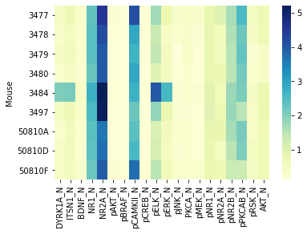

```python
import seaborn as sns

sns.heatmap(saline_expressions, cmap="YlGnBu")
```

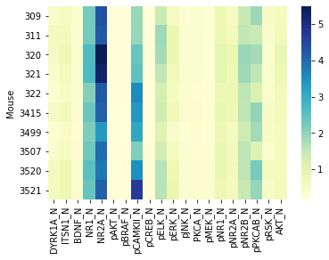

```python
sns.heatmap(memantine_expressions, cmap="YlGnBu")
```

From the heat maps, it seems that overall, expression levels for particular proteins are similar both within and between groups. However there is of course some variation. As part of our project, we may want to compare the variation within and between the groups. Furthermore, particular proteins may vary in their expression more than others. Analyzing these variations may give insight into the effects of memantine, in particular on certain proteins.

Let's repeat this process controlling for a different variable -- whether or not the mouse was stimulated to learn (shocked). We will keep constant the fact that the mice are in the control group of the study (as opposed to having down syndrome), as well as the injection (saline). The classes of interest are thus c-CS-s (stimulated) and c-SC-s (not stimulated).

```python
#We already have control_stim_saline

control_notstim_saline = df_proteins[df_proteins["class"] == "c-SC-s"]

stim_mice = saline_mice
notstim_mice = list(control_notstim_saline["Mouse"].unique())

#Grab the rows from the mean_expressions DataFrame corresponding to the mice in these two classes.
stim_expressions = mean_expressions.loc[stim_mice][df_proteins.columns[:20]]
notstim_expressions = mean_expressions.loc[notstim_mice][df_proteins.columns[:20]]
```

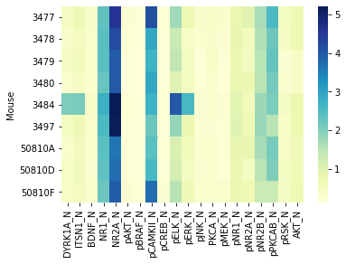

```python
sns.heatmap(stim_expressions, cmap="YlGnBu")
```

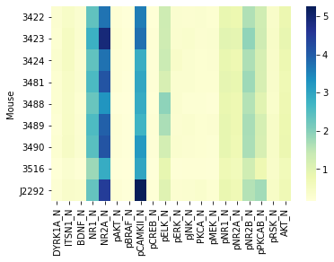

```python
sns.heatmap(notstim_expressions, cmap="YlGnBu")
```

It seems that similar conslusions to those related above can be drawn from the heatmaps of these two classes. Let's plot expressions for different classes in one four-subplot figure to allow for even easier comparison. Currently, we've only plotted three distinct classes, so I'll also generate a matrix of expression data for the c-SC-m class, which can be compared with c-SC-s, and plot the heatmap for that instead.

```python
#Yet again, use a binary mask to isolate the group "c-SC-m"
control_notstim_memantine = df_proteins[df_proteins["class"] == "c-SC-m"]
notstim_mem_mice = list(control_notstim_memantine["Mouse"].unique())

#Grab the rows from the mean_expressions DataFrame corresponding to the mice in  these two classes.
nonstim_sal_expressions = notstim_expressions #we already hve this data, so just reassign the variable
notstim_mem_expressions = mean_expressions.loc[notstim_mem_mice][df_proteins.columns[:20]]
```

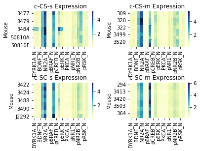

```python
#construct a matplotlib axis object with four subplots to display the four graphs
fig, axes = plt.subplots(nrows=2, ncols=2)
#make sure all the labels and titles can be seen
plt.subplots_adjust(wspace=0.4, hspace=1)

#now plot
sns.heatmap(saline_expressions, cmap="YlGnBu", ax=axes[0, 0])
axes[0, 0].set_title('c-CS-s Expression')
sns.heatmap(memantine_expressions, cmap="YlGnBu", ax=axes[0, 1])
axes[0, 1].set_title('c-CS-m Expression')
sns.heatmap(nonstim_sal_expressions, cmap="YlGnBu", ax=axes[1, 0])
axes[1, 0].set_title('c-SC-s Expression')
sns.heatmap(notstim_mem_expressions, cmap="YlGnBu", ax=axes[1, 1])
axes[1, 1].set_title('c-SC-m Expression')
```

Now we're going to analyze some of the proteins. A useful piece of analysis would be to find out which proteins have similar expression levels to determine if the proteins are possibly expressed through the same mechanism. If several proteins do have the same or similar expression mechanisms, looking at the differences in variables such as treated with saline or memantine could give us a clue what proteins or pathways memantine affects in the brain, or another variable such as being stimulated to learn. Let's take the protein pCREB_N and analyze the protein that has the most similar expression to it for mice stimulated to learn and either treated with memantine or saline.

```python
#Grab the rows from the mean_expressions DataFrame corresponding to the mice in these two classes.
from sklearn.metrics import pairwise_distances

# Making table for all the proteins for mice treated with saline and stimulated to learn
saline_expressionsA = mean_expressions.loc[saline_mice][df_proteins.columns[:len(df_proteins.columns) - 2]]

# Making table for all the proteins for mice treated with memantine and stimulated to learn
memantine_expressionsA = mean_expressions.loc[memantine_mice][df_proteins.columns[:len(df_proteins.columns) - 2]]

# Getting the mean for each protein expression for all mice in the same class
salineProteins = saline_expressionsA.mean()
memantineProteins = memantine_expressionsA.mean()

# Getting index of pCREB_N to
pCREB_N = salineProteins.index.get_loc(cool.loc["pCREB_N"].name)


# Calculating euclidean distance and finding the cloest neighbor for saline treated mice
salineProteins = salineProteins.to_frame(name = "Average Expression")
D = pairwise_distances(salineProteins, metric="euclidean")
D.shape
np.fill_diagonal(D, np.inf)
D[pCREB_N, :].argmin()
# index of closest protein is 5

salineProteins.iloc[5]
```

```
Average Expression    0.212423
Name: pAKT_N, dtype: float64
```

```python
# Calculating euclidean distance and finding the cloest neighbor for memantine treated mice
memantineProteins = memantineProteins.to_frame(name = "Average Expression")
D = pairwise_distances(memantineProteins, metric="euclidean")
D.shape
np.fill_diagonal(D, np.inf)
D[pCREB_N, :].argmin()

# index of closest protein is 56
memantineProteins.iloc[56]
```

```
Average Expression    0.194249
Name: Tau_N, dtype: float64
```

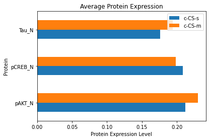

```python
# Saline Mice
sal3 = salineProteins.iloc[[5, pCREB_N, 56], :].reset_index()

# Memantine Mice
mem3 = memantineProteins.iloc[[5, pCREB_N, 56], :].reset_index()

# Making Dataframe and Graph
df = pd.merge(sal3, mem3, on='index')
df = df.rename(columns = {"index":"Protein", "Average Expression_x":"c-CS-s", "Average Expression_y": "c-CS-m"})
df = df.set_index("Protein")
ax = df.plot(kind='barh', title = "Average Protein Expression")
plt.xlabel("Protein Expression Level")
```

The bar graph above shows the expression level of a certain protein in order to directly compare the two sets of mice, those treated with saline and those treated with memantine. As we can see from this graph there isn't a huge change in expression of any of the proteins between the two sets of mice which means these proteins do not have any sort of correlation. We do have a total of 77 proteins and four different variables to compare so this will be a useful visual when looking for proteins that might have a correlation.

An important measure to consider is whether there is consistency for the expression of a protein among all the mice in that specific class. For example, below we have plotted a bar graph showing the expression of the protein pCREB_N in mice in the c-CS-s class. The expression levels do vary a little bit for this protein in each mice. We also plotted a bar graph showing the expression of the protein H3AcK18_N in mice in the c-CS-s class, which shows to have lots of varying expression levels in each mouse. This visaul can help us decide which proteins we want to do more research on because they have more consistent expression levels in mice, meaning our conclusions will be more accurate. We don't want to analyze proteins that are not affected by the experimental variables (memantine vs saline, stimulated to learn vs not stimulated to learn).

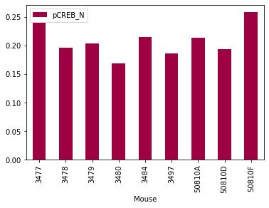

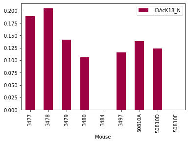

```python
from matplotlib import cm
cmap = cm.get_cmap('Spectral')
saline_expressionsA = saline_expressionsA.reset_index()

# Bar graph showing expression levels for protein pCREB_N
saline_expressionsA.plot.bar(x = "Mouse", y="pCREB_N", colormap = cmap)

# Bar graph showing expression levels for protein H3AcK18_N
saline_expressionsA.plot.bar(x = "Mouse", y="H3AcK18_N", colormap = cmap)
```